# 15时间序列预测

LJJ

2020/3/29

The purpose of this in-class lab15 is to use R to practice with **time series forecasting**. The lab15 should be completed in your group. To get credit, upload your .R script to the appropriate place on Canvas.

## 15.1 For starters

Open up a new R script (named `ICL15_XYZ.R`, where `XYZ` are your initials) and add the usual “preamble” to the top:

```r
# Add names of group members HERE
library(tidyverse)
library(wooldridge)
library(broom)
library(magrittr)
library(stargazer)
library(zoo)
library(dynlm)
library(pdfetch)
library(tseries)   # You may need to install this package
library(lubridate) # You may need to install this package
library(forecast)  # You will likely have to install this one
```

### 15.2.1 Load the data

First we’ll look at the return on a 3-month treasury bill over the period of **1960q1–1990q4**.

Second, we’ll read in Google’s and Apple’s stock price data from January 3, 2005 until October 31, 2018.

```r
df1 <- as_tibble(intqrt)
df1 %>% skimr::skim()
```

Data summary

| Name | Piped data |
| --- | --- |
| Number of rows | 124 |
| Number of columns | 23 |
| _______________________ |  |
| Column type frequency: |  |
| numeric | 23 |
| ________________________ |  |
| Group variables | None |

**Variable type: numeric**

| skim_variable | n_missing | complete_rate | mean | sd | p0 | p25 | p50 | p75 | p100 | hist |
| --- | --- | --- | --- | --- | --- | --- | --- | --- | --- | --- |
| r3 | 0 | 1.00 | 6.45 | 3.02 | 2.19 | 4.31 | 5.72 | 8.10 | 16.46 | ▇▇▃▁▁ |
| r6 | 0 | 1.00 | 6.75 | 3.11 | 2.56 | 4.47 | 6.12 | 8.38 | 17.35 | ▇▇▃▁▁ |
| r12 | 0 | 1.00 | 6.93 | 3.07 | 2.93 | 4.65 | 6.46 | 8.60 | 17.13 | ▇▆▃▁▁ |
| p3 | 0 | 1.00 | 9842.27 | 72.40 | 9605.80 | 9802.11 | 9859.40 | 9893.63 | 9945.70 | ▁▁▅▇▇ |
| p6 | 0 | 1.00 | 9676.41 | 143.05 | 9203.76 | 9598.68 | 9704.11 | 9781.85 | 9873.96 | ▁▁▃▇▇ |
| hy6 | 1 | 0.99 | 1.71 | 0.90 | 0.67 | 1.12 | 1.57 | 2.11 | 5.77 | ▇▅▁▁▁ |
| hy3 | 0 | 1.00 | 1.61 | 0.75 | 0.55 | 1.08 | 1.43 | 2.02 | 4.10 | ▇▇▃▁▁ |
| spr63 | 0 | 1.00 | 0.30 | 0.27 | -0.60 | 0.11 | 0.29 | 0.43 | 1.54 | ▁▇▇▁▁ |
| hy3_1 | 1 | 0.99 | 1.61 | 0.76 | 0.55 | 1.07 | 1.42 | 2.02 | 4.10 | ▇▇▃▁▁ |
| hy6_1 | 2 | 0.98 | 1.71 | 0.90 | 0.67 | 1.11 | 1.55 | 2.09 | 5.77 | ▇▅▁▁▁ |
| spr63_1 | 1 | 0.99 | 0.31 | 0.27 | -0.60 | 0.11 | 0.29 | 0.44 | 1.54 | ▁▇▇▁▁ |
| hy6hy3_1 | 1 | 0.99 | 0.11 | 0.34 | -0.97 | -0.04 | 0.06 | 0.21 | 1.82 | ▁▇▃▁▁ |
| cr3 | 1 | 0.99 | 0.04 | 1.25 | -6.63 | -0.28 | 0.15 | 0.60 | 4.99 | ▁▁▇▅▁ |
| r3_1 | 1 | 0.99 | 6.44 | 3.03 | 2.19 | 4.27 | 5.70 | 8.11 | 16.46 | ▇▇▃▁▁ |
| chy6 | 2 | 0.98 | 0.01 | 0.74 | -3.85 | -0.22 | 0.01 | 0.25 | 3.05 | ▁▁▇▂▁ |
| chy3 | 1 | 0.99 | 0.01 | 0.31 | -1.65 | -0.07 | 0.04 | 0.15 | 1.24 | ▁▁▇▅▁ |
| chy6_1 | 3 | 0.98 | 0.01 | 0.74 | -3.85 | -0.18 | 0.01 | 0.25 | 3.05 | ▁▁▇▂▁ |
| chy3_1 | 2 | 0.98 | 0.01 | 0.31 | -1.65 | -0.06 | 0.04 | 0.15 | 1.24 | ▁▁▇▅▁ |
| cr6 | 1 | 0.99 | 0.04 | 1.28 | -6.74 | -0.44 | 0.13 | 0.57 | 4.65 | ▁▁▇▇▁ |
| cr6_1 | 2 | 0.98 | 0.04 | 1.29 | -6.74 | -0.43 | 0.14 | 0.58 | 4.65 | ▁▁▇▇▁ |
| cr3_1 | 2 | 0.98 | 0.04 | 1.26 | -6.63 | -0.25 | 0.16 | 0.60 | 4.99 | ▁▁▇▅▁ |
| r6_1 | 1 | 0.99 | 6.74 | 3.12 | 2.56 | 4.42 | 6.10 | 8.39 | 17.35 | ▇▇▃▁▁ |
| cspr63 | 1 | 0.99 | 0.00 | 0.31 | -1.05 | -0.13 | 0.01 | 0.11 | 1.49 | ▁▅▇▁▁ |

```r
df1 %<>%
  dplyr::mutate(quarter = seq(yq('1960:Q1'),yq('1990:Q4'), by = 'quarters')) # create quarter
df1 %<>%
  dplyr::select(r3,quarter)
```

```r
df2 <- pdfetch_YAHOO(c("goog","aapl"),
                     fields = c("adjclose"),
                     from = ymd("2005-01-01"),
                     to = ymd("2018-11-01"),
                     interval = "1d") %>%
  as_tibble
df2 %<>%
  dplyr::mutate(date=rownames(df2), date=ymd(date)) # create date variable
```

### 15.2.2 Declare as time series objects

```r
df1.ts <- df1 %>%
  dplyr::select(r3) %>%
  zoo(order.by=df1$quarter)
```

```r
df2.ts <- df2 %>%
  select(goog,aapl) %>%
  dplyr::zoo(order.by=df2$date)
```

## 15.3 Plot time series data

Let’s have a look at the **3-month T-bill return for the US** over the period 1960–1990:

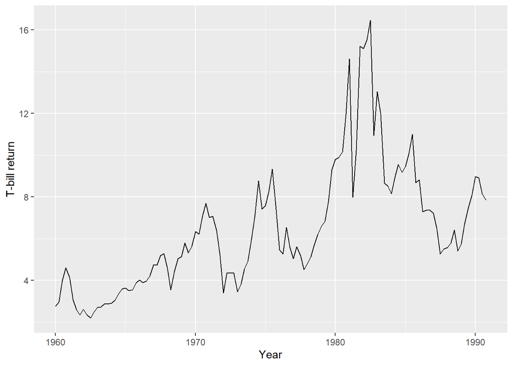

```r
autoplot(df1.ts) + xlab("Year") + ylab("T-bill return")
```

And now the Google adjusted closing price:

```r
autoplot(df2.ts) + xlab("Year") + ylab("Price")
```

## 15.4 Testing for a unit root

Let’s test for a unit root in each of the time series. The way to do this is the Augmented Dickey-Fuller (ADF) test, which is available as `adf.test()` in the `tseries` package.

The function tests

$$H_0: \text{Unit Root} \\
H_a: \text{Stationary}$$

```r
adf.test(df1.ts$r3, k=1)
```

```
##
##  Augmented Dickey-Fuller Test
##
## data:  df1.ts$r3
## Dickey-Fuller = -2.7878, Lag order = 1, p-value = 0.2492
## alternative hypothesis: stationary
```

```r
pp.test(df1.ts$r3)
```

```
##
##  Phillips-Perron Unit Root Test
##
## data:  df1.ts$r3
## Dickey-Fuller Z(alpha) = -17.53, Truncation lag parameter = 4, p-value
## = 0.1027
## alternative hypothesis: stationary
```

```r
adf.test(df2.ts$goog, k=1)
adf.test(df2.ts$aapl, k=1)
```

1. Which of these time series has a unit root, according to the ADF test? Explain what the consequences are of analyzing a time series that contains a unit root.

### 15.4.1 Estimating AR(1) models

To alternatively examine the unit root, we can estimate AR(1) models for each series:

```r
est.tbill <- dynlm(r3 ~ L(r3,1), data=df1.ts)
stargazer(est.tbill,type="text")
```

```
##
## ===============================================
##                         Dependent variable:
##                     ---------------------------
##                                 r3
## -----------------------------------------------
## L(r3, 1)                     0.909***
##                               (0.037)
##
## Constant                      0.625**
##                               (0.261)
##
## -----------------------------------------------
## Observations                    123
## R2                             0.836
## Adjusted R2                    0.834
## Residual Std. Error      1.228 (df = 121)
## F Statistic          614.595*** (df = 1; 121)
## ===============================================
## Note:               *p<0.1; **p<0.05; ***p<0.01
```

```r
est.goog  <- dynlm(goog ~ L(goog,1), data=df2.ts)
stargazer(est.goog,type="text")

est.aapl  <- dynlm(aapl ~ L(aapl,1), data=df2.ts)
stargazer(est.aapl,type="text")
```

2. Are the $R^2$ values from these estimates meaningful?

## 15.5 Forecasting

Now let’s use our time series data to forecast future stock prices. First, we should create a shortened version of the time series so we can compare our forecast to actual data:

```r
df2.short    <- df2 %>%
  dplyr::filter(date < as.Date("2018-10-01"))

df2.ts.short <- df2.short %>%
  dplyr::select(goog,aapl) %>%
  zoo(order.by=df2.short$date)
```

### 15.5.1 Estimating simple AR models

We can use the `Arima` function to estimate basic AR(1) models on the **differenced stock prices**.

```r
simple.goog <- Arima(df2.ts.short$goog,order=c(1,1,0))
simple.aapl <- Arima(df2.ts.short$aapl,order=c(1,1,0))
```

This is the same thing as estimating

$$\Delta goog_t = \rho \Delta goog_{t-1} + u_t$$

### 15.5.2 Estimating ARIMA models

We can also use the `auto.arima` function to allow the computer to choose the best ARIMA model:

```r
auto.goog <- auto.arima(df2.ts.short$goog)
auto.aapl <- auto.arima(df2.ts.short$aapl)
```

### 15.5.3 Plotting forecasts

We can compare the 90-day-ahead forecasts of each model by looking at their plots:

```r
autoplot(forecast(simple.goog, h=90))
autoplot(forecast(  auto.goog, h=90))

autoplot(forecast(simple.aapl, h=90))
autoplot(forecast(  auto.aapl, h=90))
```